# Slab + interval stats and geoms

### Annotating slabs with spikes

`geom_spike()` and `stat_spike()` make it straightforward to apply custom “spike” annotations to slabs. The easiest way to use spikes is to use `stat_spike()` and pass it a numeric position or a function giving numeric position(s) at which you wish to place a spike (or a list of these). If passed a function, the function will be applied to the *distributional* or `posterior::rvar()` object used internally to represent the distribution.

This means that point estimates (e.g., `mean()`, `median()`, `Mode()`), quantiles (`quantile()`), and interval estimates (`qi()`, `hdci()`, `hdi()`) can be provided to `stat_spike()` directly. This makes it easy to modify the previous example to highlight how medians and quantile intervals differ from modes and highest-density intervals in terms of their densities:

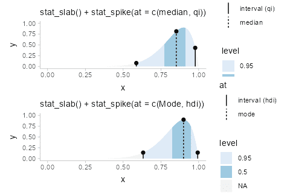

```r
qi_plot_spikes = data.frame(dist = dist_beta(10, 2)) %>%
  ggplot(aes(xdist = dist)) +
  stat_slab(aes(fill = after_stat(level)), point_interval = median_qi, .width = c(.5, .95)) +
  # stat_spike(at = c(median, qi)) would also work, but this demonstrates how
  # to re-label the names of the `at` computed variable and use it in an
  # aesthetic mapping by mapping it to `linetype`
  stat_spike(aes(linetype = after_stat(at)), at = c("median", "interval (qi)" = qi)) +
  scale_fill_brewer(na.value = "gray95") +
  scale_thickness_shared() +
  labs(subtitle = "stat_slab() + stat_spike(at = c(median, qi))")

hdi_plot_spikes = data.frame(dist = dist_beta(10, 2)) %>%
  ggplot(aes(xdist = dist)) +
  stat_slab(aes(fill = after_stat(level)), point_interval = mode_hdi, .width = c(.5, .95)) +
  stat_spike(aes(linetype = after_stat(at)), at = c("mode" = Mode, "interval (hdi)" = hdi)) +
  scale_fill_brewer(na.value = "gray95") +
  scale_thickness_shared() +
  labs(subtitle = "stat_slab() + stat_spike(at = c(Mode, hdi))")

qi_plot_spikes /
  hdi_plot_spikes
```

Note the use of `scale_thickness_shared()`, which ensures that the `thickness` values for the slabs and the `thickness` values for the spikes (which determine their heights) use a shared scale, so they line up correctly.

### Using color ramps for `fill` and `color` aesthetics

`ggdist` supplies `color_ramp` (or `colour_ramp`) and `fill_ramp` aesthetics which can be used to vary (“ramp”) the outline or fill colors smoothly from a base color (default `"white"`) to whatever color the geometry would otherwise have.

Taking the above example with interval-filled slabs, we could use the `fill_ramp` aesthetic instead of the `fill` aesthetic to set the slab color based on the interval it is in. We could then vary the base fill color separately from the interval based on another column in the original data table, such as the `subgroup` column:

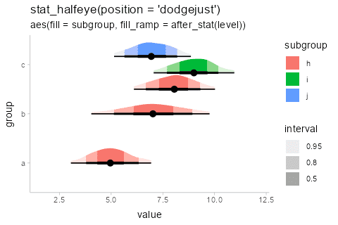

```r
df %>%
  ggplot(aes(y = group, x = value)) +
  stat_halfeye(
    aes(fill = subgroup, fill_ramp = after_stat(level)),
    .width = c(.50, .80, .95),
    # NOTE: we use position = "dodgejust" (a dodge that respects the
    # justification of intervals relative to slabs) instead of
    # position = "dodge" here because it ensures the topmost slab does
    # not extend beyond the plot limits
    position = "dodgejust"
  ) +
  # a range from 1 down to 0.2 ensures the fill goes dark to light inside-out
  # and doesn't get all the way down to white (0) on the lightest color
  scale_fill_ramp_discrete(na.translate = FALSE) +
  labs(
    title = "stat_halfeye(position = 'dodgejust')",
    subtitle = "aes(fill = subgroup, fill_ramp = after_stat(level))",
    fill_ramp = "interval"
  )
```

We could similarly use `stat_interval()` with the `color_ramp` aesthetic to vary subgroup color separately from the whiteness of the intervals. Here, `level` is a variable generated by all stats in the `stat_slabinterval()` family which contains the level of the generated intervals, as an ordered factor.

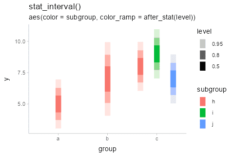

```r
dist_df %>%
  ggplot(aes(x = group, ydist = dist_normal(mean, sd), color = subgroup)) +
  stat_interval(aes(color_ramp = after_stat(level)), position = "dodge") +
  labs(
    title = "stat_interval()",
    subtitle = "aes(color = subgroup, color_ramp = after_stat(level))"
  )
```

See `help("scale_color_ramp")` for more information on the color ramp aesthetics/scales.

### Raindrop plots

[Barrowman and Myers](https://doi.org/10.1198/0003130032369) proposed an alternative to density-based eye plots (such as created by `stat_eye()` by default) called *raindrop plots*. In these, the thickness of the slab is proportional to `log(pdf)` instead of `pdf`, and is bounded within the 95% interval. We can construct a function that uses the `pdf` and `.width` computed variables to give a thickness proportional to `log(pdf)` within the 95% interval, and use it to create raindrop plots.

Barrowman and Myers apply this technique with a 95% raindrop superimposed on a 99% raindrop, which we can replicate:

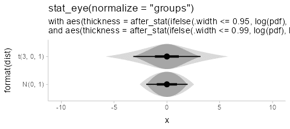

```r
priors %>%
  ggplot(aes(y = format(dist), xdist = dist)) +
  # must also use normalize = "groups" because min(log(pdf)) will be different for each dist
  stat_slab(
    aes(thickness = after_stat(ifelse(.width <= 0.99, log(pdf), NA))),
    normalize = "groups", fill = "gray85", .width = .99, side = "both"
  ) +
  stat_eye(
    aes(thickness = after_stat(ifelse(.width <= 0.95, log(pdf), NA))),
    normalize = "groups"
  ) +
  ggtitle(
    'stat_eye(normalize = "groups")',
    paste0(
      "with aes(thickness = after_stat(ifelse(.width <= 0.95, log(pdf), NA)))\n",
      "and aes(thickness = after_stat(ifelse(.width <= 0.99, log(pdf), NA)))"
    )
  )
```

### Creating ridge plots

When plotting densities (as in `stat_halfeye()`, `stat_slab()`, etc) it can be useful to overplot many densities simultaneously, an approach sometimes called *ridge plots* (e.g. as in the [ggridges](https://wilkelab.org/ggridges/) package). This can be done by setting `scale` or `height` to a value greater than 1. Setting `height` is often the best approach as it will correctly adjust plot boundaries (unless you need to use `position = "dodge"`, in which case you should use `scale` and adjust plot boundaries manually).

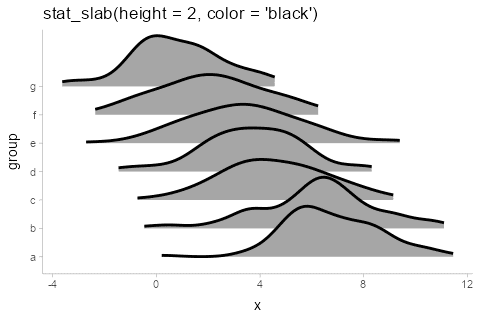

```r
set.seed(1234)

ridges_df = data.frame(
  group = letters[7:1],
  x = rnorm(700, mean = 1:7, sd = 2)
)

ridges_df %>%
  ggplot(aes(y = group, x = x)) +
  stat_slab(height = 2, color = "black") +
  ggtitle("stat_slab(height = 2, color = 'black')")
```

Depending on if it makes sense for your data (for example, if the scale is unbounded), you may also wish to adjust the `density` and `trim` parameters. The default `density`, `density_bounded()`, estimates the bounds of the distribution, which is useful if your data has natural boundaries (e.g., is restricted to be positive). But if you know the underlying distribution is unbounded, you can set `density = "unbounded"`. You may also want to set `trim` to `FALSE` to ensure the densities smoothly go down to 0, rather than being cut off at the limits of the raw data. Combining both of these with `expand = TRUE` will make each slab expand itself to the limits of the `x` axis.

We’ll use `density`, `trim`, and `expand` along with a combination of `fill` and `fill_ramp` to give each group on the y axis a different color and to vary the fill along the `x` axis in a way that provides a “softer” form of region of practical equivalence:

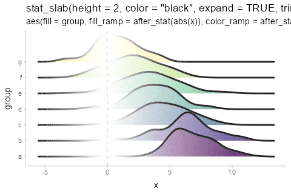

```r
ridges_df %>%
  ggplot(aes(
    y = group, x = x,
    fill = group, fill_ramp = after_stat(abs(x)),
    color_ramp = after_stat(-dnorm(x, 0, 2))
  )) +
  stat_slab(
    height = 2, color = "gray15",
    expand = TRUE, trim = FALSE, density = "unbounded",
    fill_type = "gradient",
    show.legend = FALSE
  ) +
  geom_vline(xintercept = 0, color = "gray85", linetype = "dashed") +
  ggtitle(
    'stat_slab(height = 2, color = "black", expand = TRUE, trim = FALSE)',
    'aes(fill = group, fill_ramp = after_stat(abs(x)), color_ramp = after_stat(-dnorm(x, 0, 2)))'
  ) +
  scale_fill_viridis_d()
```

We use a tighter ramp on `color` compared to `fill` (via `-dnorm()` instead of `abs()`) because we want the outlines to quickly ramp back to black outside of 0 so that they have sufficient contrast against the slabs when they overlap.

### Varying side, scale, and justification within geoms

The `side`, `scale`, and `justification` parameters can also be varied within all geoms in the `geom_slabinterval()` family, allowing (for example) different groups to hang above or below the interval:

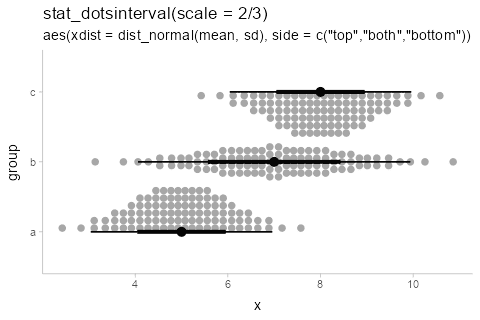

```r
dist_df %>%
  filter(subgroup == "h") %>%
  mutate(side = c("top", "both", "bottom")) %>%
  ggplot(aes(y = group, xdist = dist_normal(mean, sd), side = side)) +
  stat_dotsinterval(scale = 2/3) +
  labs(
    title = 'stat_dotsinterval(scale = 2/3)',
    subtitle = 'aes(xdist = dist_normal(mean, sd), side = c("top","both","bottom"))'
  ) +
  coord_cartesian()
```

### Multiple slabs and intervals in composite plots

Sometimes you may want to include multiple different types of slabs in the same plot in order to take advantage of the features each slab type provides. For example, people often combine densities with dotplots to show the underlying datapoints that go into a density estimate, creating so-called “rain cloud” plots.

To use multiple slab geometries together, you can use the `side` parameter to change which side of the interval a slab is drawn on and set the `scale` parameter to something around `0.5` (by default it is `0.9`) so that the two slabs do not overlap. Geoms can also be dodged together, as in this example using densities with quantile dotplots in subgroups. This example also shows how `stat_pointinterval()` can be repurposed to be used with other geoms; here to replace points with labels (the idea of replacing points with labels comes from Brenton Wiernik).

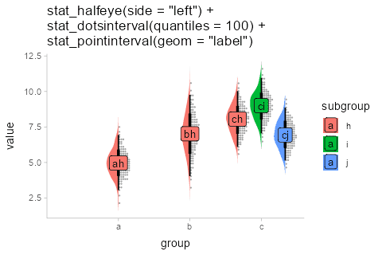

```r
df %>%
  ggplot(aes(x = group, y = value, fill = subgroup)) +
  stat_slab(side = "left", scale = 0.5, position = "dodge") +
  stat_dotsinterval(scale = 0.5, quantiles = 100, position = "dodge") +
  stat_pointinterval(
    geom = "label",
    aes(label = paste0(group, subgroup)),
    .width = .5,  # set to a scalar to draw only one label instead of two
    position = position_dodge(width = 1),
    size = 3.5
  ) +
  labs(title = paste0(
    'stat_halfeye(side = "left") +\n',
    'stat_dotsinterval(quantiles = 100) +\n',
    'stat_pointinterval(geom = "label")'
  ))
```

When constructing composite plots it may be useful to position the slab and interval parts of the geometry separately. While some relative positioning of these geometries is supported by manipulating the `justification` parameter, if you want complete, separate control over positioning of intervals versus slabs, the simplest approach can be to specify those geometries separately.

For example, the following uses a separate specification of a `stat_slab()` and a `stat_pointinterval()` instead of a combined `stat_slabinterval()` in order to use `position_dodgejust()` on the intervals but not the slabs:

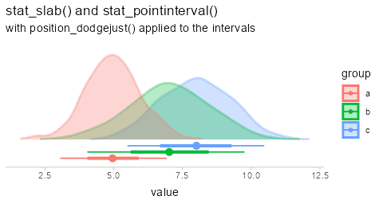

```r
df %>%
  ggplot(aes(fill = group, color = group, x = value)) +
  stat_slab(alpha = .3) +
  stat_pointinterval(position = position_dodgejust(width = .2), justification = 0.1) +
  labs(
    title = "stat_slab() and stat_pointinterval()",
    subtitle = "with position_dodgejust() applied to the intervals",
    y = NULL
  ) +
  scale_y_continuous(breaks = NULL)
```

(Thanks to Brenton Wiernik for [this example](https://github.com/mjskay/ggdist/issues/27#issuecomment-725578437).)